# Risk Factor Analysis

## Outcome Variable

**Outcome Variable:** stunted

## Predictor Variables

**Intervention Variable:** hdlvry

**Adjustment Set:**

- arm
- sex
- W_mage
- meducyrs
- W_nrooms
- brthmon
- W_parity
- impsan
- delta_W_mage
- delta_meducyrs
- delta_W_nrooms
- delta_brthmon
- delta_W_parity
- delta_impsan

## Stratifying Variables

The analysis was stratified on these variable(s):

- agecat
- studyid
- country

## Data Summary

| agecat | studyid | country | hdlvry | stunted | n_cell | n |
| --- | --- | --- | --- | --- | --- | --- |
| Birth | ki1000108-CMC-V-BCS-2002 | INDIA | 0 | 0 | 74 | 90 |
| Birth | ki1000108-CMC-V-BCS-2002 | INDIA | 0 | 1 | 16 | 90 |
| Birth | ki1000108-CMC-V-BCS-2002 | INDIA | 1 | 0 | 0 | 90 |
| Birth | ki1000108-CMC-V-BCS-2002 | INDIA | 1 | 1 | 0 | 90 |
| Birth | ki1000108-IRC | INDIA | 0 | 0 | 337 | 388 |
| Birth | ki1000108-IRC | INDIA | 0 | 1 | 44 | 388 |
| Birth | ki1000108-IRC | INDIA | 1 | 0 | 6 | 388 |
| Birth | ki1000108-IRC | INDIA | 1 | 1 | 1 | 388 |
| Birth | ki1000109-EE | PAKISTAN | 0 | 0 | 1 | 2 |
| Birth | ki1000109-EE | PAKISTAN | 0 | 1 | 1 | 2 |
| Birth | ki1000109-EE | PAKISTAN | 1 | 0 | 0 | 2 |
| Birth | ki1000109-EE | PAKISTAN | 1 | 1 | 0 | 2 |
| Birth | ki1000304b-SAS-CompFeed | INDIA | 0 | 0 | 6 | 180 |
| Birth | ki1000304b-SAS-CompFeed | INDIA | 0 | 1 | 5 | 180 |
| Birth | ki1000304b-SAS-CompFeed | INDIA | 1 | 0 | 129 | 180 |
| Birth | ki1000304b-SAS-CompFeed | INDIA | 1 | 1 | 40 | 180 |
| Birth | ki1017093c-NIH-Crypto | BANGLADESH | 0 | 0 | 18 | 27 |
| Birth | ki1017093c-NIH-Crypto | BANGLADESH | 0 | 1 | 4 | 27 |
| Birth | ki1017093c-NIH-Crypto | BANGLADESH | 1 | 0 | 4 | 27 |
| Birth | ki1017093c-NIH-Crypto | BANGLADESH | 1 | 1 | 1 | 27 |
| Birth | ki1135781-COHORTS | INDIA | 0 | 0 | 2613 | 4694 |
| Birth | ki1135781-COHORTS | INDIA | 0 | 1 | 325 | 4694 |
| Birth | ki1135781-COHORTS | INDIA | 1 | 0 | 1534 | 4694 |
| Birth | ki1135781-COHORTS | INDIA | 1 | 1 | 222 | 4694 |
| Birth | kiGH5241-JiVitA-3 | BANGLADESH | 0 | 0 | 6 | 300 |
| Birth | kiGH5241-JiVitA-3 | BANGLADESH | 0 | 1 | 5 | 300 |
| Birth | kiGH5241-JiVitA-3 | BANGLADESH | 1 | 0 | 213 | 300 |
| Birth | kiGH5241-JiVitA-3 | BANGLADESH | 1 | 1 | 76 | 300 |
| Birth | kiGH5241-JiVitA-4 | BANGLADESH | 0 | 0 | 37 | 820 |
| Birth | kiGH5241-JiVitA-4 | BANGLADESH | 0 | 1 | 10 | 820 |

[output cut: 86 more lines]

The following strata were considered:

- agecat: 24 months, studyid: ki1000108-CMC-V-BCS-2002, country: INDIA
- agecat: 24 months, studyid: ki1000108-IRC, country: INDIA
- agecat: 24 months, studyid: ki1017093b-PROVIDE, country: BANGLADESH
- agecat: 24 months, studyid: ki1017093c-NIH-Crypto, country: BANGLADESH
- agecat: 24 months, studyid: ki1066203-TanzaniaChild2, country: TANZANIA, UNITED REPUBLIC OF
- agecat: 24 months, studyid: ki1113344-GMS-Nepal, country: NEPAL
- agecat: 24 months, studyid: ki1135781-COHORTS, country: INDIA
- agecat: 24 months, studyid: kiGH5241-JiVitA-3, country: BANGLADESH
- agecat: 24 months, studyid: kiGH5241-JiVitA-4, country: BANGLADESH
- agecat: 6 months, studyid: ki1000108-CMC-V-BCS-2002, country: INDIA
- agecat: 6 months, studyid: ki1000108-IRC, country: INDIA
- agecat: 6 months, studyid: ki1000109-EE, country: PAKISTAN
- agecat: 6 months, studyid: ki1000304b-SAS-CompFeed, country: INDIA
- agecat: 6 months, studyid: ki1000304b-SAS-FoodSuppl, country: INDIA
- agecat: 6 months, studyid: ki1017093b-PROVIDE, country: BANGLADESH
- agecat: 6 months, studyid: ki1017093c-NIH-Crypto, country: BANGLADESH
- agecat: 6 months, studyid: ki1066203-TanzaniaChild2, country: TANZANIA, UNITED REPUBLIC OF
- agecat: 6 months, studyid: ki1113344-GMS-Nepal, country: NEPAL
- agecat: 6 months, studyid: ki1135781-COHORTS, country: INDIA
- agecat: 6 months, studyid: kiGH5241-JiVitA-3, country: BANGLADESH
- agecat: 6 months, studyid: kiGH5241-JiVitA-4, country: BANGLADESH
- agecat: Birth, studyid: ki1000108-CMC-V-BCS-2002, country: INDIA
- agecat: Birth, studyid: ki1000108-IRC, country: INDIA
- agecat: Birth, studyid: ki1000109-EE, country: PAKISTAN
- agecat: Birth, studyid: ki1000304b-SAS-CompFeed, country: INDIA
- agecat: Birth, studyid: ki1017093c-NIH-Crypto, country: BANGLADESH
- agecat: Birth, studyid: ki1135781-COHORTS, country: INDIA
- agecat: Birth, studyid: kiGH5241-JiVitA-3, country: BANGLADESH
- agecat: Birth, studyid: kiGH5241-JiVitA-4, country: BANGLADESH

### Dropped Strata

Some strata were dropped due to rare outcomes:

- agecat: Birth, studyid: ki1000108-CMC-V-BCS-2002, country: INDIA
- agecat: Birth, studyid: ki1000108-IRC, country: INDIA
- agecat: Birth, studyid: ki1000109-EE, country: PAKISTAN
- agecat: Birth, studyid: ki1017093c-NIH-Crypto, country: BANGLADESH
- agecat: 6 months, studyid: ki1000108-CMC-V-BCS-2002, country: INDIA
- agecat: 6 months, studyid: ki1000108-IRC, country: INDIA
- agecat: 24 months, studyid: ki1000108-CMC-V-BCS-2002, country: INDIA
- agecat: 24 months, studyid: ki1000108-IRC, country: INDIA
- agecat: 24 months, studyid: ki1066203-TanzaniaChild2, country: TANZANIA, UNITED REPUBLIC OF

## Methods Detail

We’re interested in the causal parameters $E[Y_a]$ for all values of $a \in \mathcal{A}$. These parameters represent the mean outcome if, possibly contrary to fact, we intervened to set all units to have $A=a$. Under the randomization and positivity assumptions, these are identified by the statistical parameters $\psi_a=E_W[E_{Y|A,W}(Y|A=a,W)]$. In addition, we’re interested in the mean of $Y$, $E[Y]$ under no intervention (the observed mean). We will estimate these parameters by using SuperLearner to fit the relevant likelihood factors – $E_{Y|A,W}(Y|A=a,W)$ and $p(A=a|W)$, and then updating our likelihood fit using a joint TMLE.

For unadjusted analyses ($W=\{\}$), initial likelihoods were estimated using Lrnr_glm to estimate the simple $E(Y|A)$ and Lrnr_mean to estimate $p(A)$. For adjusted analyses, a small library containing Lrnr_glmnet, Lrnr_xgboost, and Lrnr_mean was used.

Having estimated these parameters, we will then use the delta method to estimate relative risks and attributable risks relative to a prespecified baseline level of $A$.

# Results Detail

## Results Plots

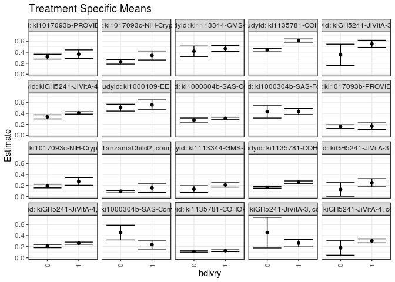

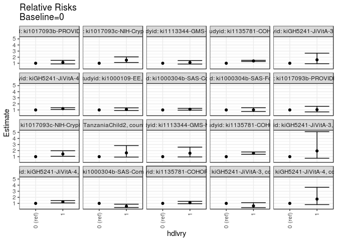

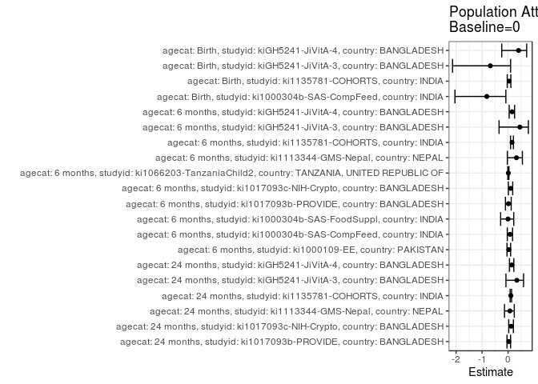

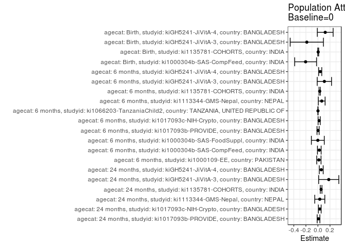

## Results Table

### Parameter: TSM

| agecat | studyid | country | intervention_level | baseline_level | estimate | ci_lower | ci_upper |
| --- | --- | --- | --- | --- | --- | --- | --- |
| Birth | ki1000304b-SAS-CompFeed | INDIA | 0 | NA | 0.4545455 | 0.3211332 | 0.5879577 |
| Birth | ki1000304b-SAS-CompFeed | INDIA | 1 | NA | 0.2366864 | 0.1571441 | 0.3162286 |
| Birth | ki1135781-COHORTS | INDIA | 0 | NA | 0.1120909 | 0.1000332 | 0.1241486 |
| Birth | ki1135781-COHORTS | INDIA | 1 | NA | 0.1257328 | 0.1089822 | 0.1424834 |
| Birth | kiGH5241-JiVitA-3 | BANGLADESH | 0 | NA | 0.4545455 | 0.1768203 | 0.7322707 |
| Birth | kiGH5241-JiVitA-3 | BANGLADESH | 1 | NA | 0.2629758 | 0.1953339 | 0.3306176 |
| Birth | kiGH5241-JiVitA-4 | BANGLADESH | 0 | NA | 0.1790524 | 0.0442707 | 0.3138341 |
| Birth | kiGH5241-JiVitA-4 | BANGLADESH | 1 | NA | 0.3052042 | 0.2685301 | 0.3418782 |
| 6 months | ki1000109-EE | PAKISTAN | 0 | NA | 0.5034057 | 0.4410511 | 0.5657604 |
| 6 months | ki1000109-EE | PAKISTAN | 1 | NA | 0.5531825 | 0.4640744 | 0.6422906 |
| 6 months | ki1000304b-SAS-CompFeed | INDIA | 0 | NA | 0.2771157 | 0.2407162 | 0.3135151 |
| 6 months | ki1000304b-SAS-CompFeed | INDIA | 1 | NA | 0.3059842 | 0.2836611 | 0.3283072 |
| 6 months | ki1000304b-SAS-FoodSuppl | INDIA | 0 | NA | 0.4306605 | 0.3128362 | 0.5484848 |
| 6 months | ki1000304b-SAS-FoodSuppl | INDIA | 1 | NA | 0.4345492 | 0.3784622 | 0.4906361 |
| 6 months | ki1017093b-PROVIDE | BANGLADESH | 0 | NA | 0.1588374 | 0.1244329 | 0.1932420 |
| 6 months | ki1017093b-PROVIDE | BANGLADESH | 1 | NA | 0.1662018 | 0.1053418 | 0.2270617 |
| 6 months | ki1017093c-NIH-Crypto | BANGLADESH | 0 | NA | 0.1893337 | 0.1566898 | 0.2219775 |
| 6 months | ki1017093c-NIH-Crypto | BANGLADESH | 1 | NA | 0.2733507 | 0.2030687 | 0.3436328 |
| 6 months | ki1066203-TanzaniaChild2 | TANZANIA, UNITED REPUBLIC OF | 0 | NA | 0.0963473 | 0.0829238 | 0.1097708 |
| 6 months | ki1066203-TanzaniaChild2 | TANZANIA, UNITED REPUBLIC OF | 1 | NA | 0.1562500 | 0.0724034 | 0.2400966 |
| 6 months | ki1113344-GMS-Nepal | NEPAL | 0 | NA | 0.1343479 | 0.0734828 | 0.1952130 |
| 6 months | ki1113344-GMS-Nepal | NEPAL | 1 | NA | 0.2100961 | 0.1699813 | 0.2502109 |
| 6 months | ki1135781-COHORTS | INDIA | 0 | NA | 0.1660322 | 0.1511547 | 0.1809097 |
| 6 months | ki1135781-COHORTS | INDIA | 1 | NA | 0.2603145 | 0.2381652 | 0.2824639 |
| 6 months | kiGH5241-JiVitA-3 | BANGLADESH | 0 | NA | 0.1282051 | 0.0052540 | 0.2511562 |
| 6 months | kiGH5241-JiVitA-3 | BANGLADESH | 1 | NA | 0.2491468 | 0.1752336 | 0.3230600 |
| 6 months | kiGH5241-JiVitA-4 | BANGLADESH | 0 | NA | 0.2107738 | 0.1812273 | 0.2403204 |
| 6 months | kiGH5241-JiVitA-4 | BANGLADESH | 1 | NA | 0.2626070 | 0.2432169 | 0.2819972 |
| 24 months | ki1017093b-PROVIDE | BANGLADESH | 0 | NA | 0.3197736 | 0.2757878 | 0.3637594 |
| 24 months | ki1017093b-PROVIDE | BANGLADESH | 1 | NA | 0.3646365 | 0.2862267 | 0.4430464 |
| 24 months | ki1017093c-NIH-Crypto | BANGLADESH | 0 | NA | 0.2262158 | 0.1846243 | 0.2678072 |
| 24 months | ki1017093c-NIH-Crypto | BANGLADESH | 1 | NA | 0.3414685 | 0.2592081 | 0.4237289 |
| 24 months | ki1113344-GMS-Nepal | NEPAL | 0 | NA | 0.4169636 | 0.3218093 | 0.5121178 |
| 24 months | ki1113344-GMS-Nepal | NEPAL | 1 | NA | 0.4664169 | 0.4137617 | 0.5190722 |
| 24 months | ki1135781-COHORTS | INDIA | 0 | NA | 0.4436573 | 0.4221322 | 0.4651825 |
| 24 months | ki1135781-COHORTS | INDIA | 1 | NA | 0.6111381 | 0.5818582 | 0.6404179 |
| 24 months | kiGH5241-JiVitA-3 | BANGLADESH | 0 | NA | 0.3531725 | 0.1605512 | 0.5457939 |
| 24 months | kiGH5241-JiVitA-3 | BANGLADESH | 1 | NA | 0.5520327 | 0.4868870 | 0.6171784 |
| 24 months | kiGH5241-JiVitA-4 | BANGLADESH | 0 | NA | 0.3358061 | 0.2980838 | 0.3735284 |
| 24 months | kiGH5241-JiVitA-4 | BANGLADESH | 1 | NA | 0.4074916 | 0.3860404 | 0.4289428 |

### Parameter: E(Y)

| agecat | studyid | country | intervention_level | baseline_level | estimate | ci_lower | ci_upper |
| --- | --- | --- | --- | --- | --- | --- | --- |
| Birth | ki1000304b-SAS-CompFeed | INDIA | NA | NA | 0.2500000 | 0.1698155 | 0.3301845 |
| Birth | ki1135781-COHORTS | INDIA | NA | NA | 0.1165317 | 0.1073518 | 0.1257117 |
| Birth | kiGH5241-JiVitA-3 | BANGLADESH | NA | NA | 0.2700000 | 0.2043793 | 0.3356207 |
| Birth | kiGH5241-JiVitA-4 | BANGLADESH | NA | NA | 0.3000000 | 0.2644043 | 0.3355957 |
| 6 months | ki1000109-EE | PAKISTAN | NA | NA | 0.5189189 | 0.4679396 | 0.5698982 |
| 6 months | ki1000304b-SAS-CompFeed | INDIA | NA | NA | 0.2997250 | 0.2767096 | 0.3227405 |
| 6 months | ki1000304b-SAS-FoodSuppl | INDIA | NA | NA | 0.4289474 | 0.3791199 | 0.4787748 |
| 6 months | ki1017093b-PROVIDE | BANGLADESH | NA | NA | 0.1612350 | 0.1313580 | 0.1911120 |
| 6 months | ki1017093c-NIH-Crypto | BANGLADESH | NA | NA | 0.2097902 | 0.1799252 | 0.2396552 |
| 6 months | ki1066203-TanzaniaChild2 | TANZANIA, UNITED REPUBLIC OF | NA | NA | 0.0973451 | 0.0840860 | 0.1106043 |
| 6 months | ki1113344-GMS-Nepal | NEPAL | NA | NA | 0.1973435 | 0.1633315 | 0.2313554 |
| 6 months | ki1135781-COHORTS | INDIA | NA | NA | 0.1955735 | 0.1842315 | 0.2069155 |
| 6 months | kiGH5241-JiVitA-3 | BANGLADESH | NA | NA | 0.2349398 | 0.1664503 | 0.3034292 |
| 6 months | kiGH5241-JiVitA-4 | BANGLADESH | NA | NA | 0.2486379 | 0.2325647 | 0.2647112 |
| 24 months | ki1017093b-PROVIDE | BANGLADESH | NA | NA | 0.3292894 | 0.2909105 | 0.3676684 |
| 24 months | ki1017093c-NIH-Crypto | BANGLADESH | NA | NA | 0.2568093 | 0.2190047 | 0.2946140 |
| 24 months | ki1113344-GMS-Nepal | NEPAL | NA | NA | 0.4475375 | 0.4023913 | 0.4926837 |
| 24 months | ki1135781-COHORTS | INDIA | NA | NA | 0.4964878 | 0.4800590 | 0.5129165 |
| 24 months | kiGH5241-JiVitA-3 | BANGLADESH | NA | NA | 0.5326460 | 0.4663548 | 0.5989373 |
| 24 months | kiGH5241-JiVitA-4 | BANGLADESH | NA | NA | 0.3907615 | 0.3719765 | 0.4095466 |

### Parameter: RR

| agecat | studyid | country | intervention_level | baseline_level | estimate | ci_lower | ci_upper |
| --- | --- | --- | --- | --- | --- | --- | --- |
| Birth | ki1000304b-SAS-CompFeed | INDIA | 0 | 0 | 1.0000000 | 1.0000000 | 1.0000000 |
| Birth | ki1000304b-SAS-CompFeed | INDIA | 1 | 0 | 0.5207101 | 0.3121948 | 0.8684928 |
| Birth | ki1135781-COHORTS | INDIA | 0 | 0 | 1.0000000 | 1.0000000 | 1.0000000 |
| Birth | ki1135781-COHORTS | INDIA | 1 | 0 | 1.1217040 | 0.9453153 | 1.3310055 |
| Birth | kiGH5241-JiVitA-3 | BANGLADESH | 0 | 0 | 1.0000000 | 1.0000000 | 1.0000000 |
| Birth | kiGH5241-JiVitA-3 | BANGLADESH | 1 | 0 | 0.5785467 | 0.2994589 | 1.1177370 |
| Birth | kiGH5241-JiVitA-4 | BANGLADESH | 0 | 0 | 1.0000000 | 1.0000000 | 1.0000000 |
| Birth | kiGH5241-JiVitA-4 | BANGLADESH | 1 | 0 | 1.7045522 | 0.7973123 | 3.6441158 |
| 6 months | ki1000109-EE | PAKISTAN | 0 | 0 | 1.0000000 | 1.0000000 | 1.0000000 |
| 6 months | ki1000109-EE | PAKISTAN | 1 | 0 | 1.0988801 | 0.8960334 | 1.3476477 |
| 6 months | ki1000304b-SAS-CompFeed | INDIA | 0 | 0 | 1.0000000 | 1.0000000 | 1.0000000 |
| 6 months | ki1000304b-SAS-CompFeed | INDIA | 1 | 0 | 1.1041749 | 0.9636102 | 1.2652442 |
| 6 months | ki1000304b-SAS-FoodSuppl | INDIA | 0 | 0 | 1.0000000 | 1.0000000 | 1.0000000 |
| 6 months | ki1000304b-SAS-FoodSuppl | INDIA | 1 | 0 | 1.0090296 | 0.7450898 | 1.3664670 |
| 6 months | ki1017093b-PROVIDE | BANGLADESH | 0 | 0 | 1.0000000 | 1.0000000 | 1.0000000 |
| 6 months | ki1017093b-PROVIDE | BANGLADESH | 1 | 0 | 1.0463640 | 0.6836408 | 1.6015391 |
| 6 months | ki1017093c-NIH-Crypto | BANGLADESH | 0 | 0 | 1.0000000 | 1.0000000 | 1.0000000 |
| 6 months | ki1017093c-NIH-Crypto | BANGLADESH | 1 | 0 | 1.4437513 | 1.0590745 | 1.9681503 |
| 6 months | ki1066203-TanzaniaChild2 | TANZANIA, UNITED REPUBLIC OF | 0 | 0 | 1.0000000 | 1.0000000 | 1.0000000 |
| 6 months | ki1066203-TanzaniaChild2 | TANZANIA, UNITED REPUBLIC OF | 1 | 0 | 1.6217376 | 0.9315439 | 2.8233055 |
| 6 months | ki1113344-GMS-Nepal | NEPAL | 0 | 0 | 1.0000000 | 1.0000000 | 1.0000000 |
| 6 months | ki1113344-GMS-Nepal | NEPAL | 1 | 0 | 1.5638212 | 0.9538935 | 2.5637420 |
| 6 months | ki1135781-COHORTS | INDIA | 0 | 0 | 1.0000000 | 1.0000000 | 1.0000000 |
| 6 months | ki1135781-COHORTS | INDIA | 1 | 0 | 1.5678559 | 1.3860353 | 1.7735276 |
| 6 months | kiGH5241-JiVitA-3 | BANGLADESH | 0 | 0 | 1.0000000 | 1.0000000 | 1.0000000 |
| 6 months | kiGH5241-JiVitA-3 | BANGLADESH | 1 | 0 | 1.9433447 | 0.7402346 | 5.1018808 |
| 6 months | kiGH5241-JiVitA-4 | BANGLADESH | 0 | 0 | 1.0000000 | 1.0000000 | 1.0000000 |
| 6 months | kiGH5241-JiVitA-4 | BANGLADESH | 1 | 0 | 1.2459186 | 1.0648722 | 1.4577459 |
| 24 months | ki1017093b-PROVIDE | BANGLADESH | 0 | 0 | 1.0000000 | 1.0000000 | 1.0000000 |
| 24 months | ki1017093b-PROVIDE | BANGLADESH | 1 | 0 | 1.1402959 | 0.8829197 | 1.4726988 |
| 24 months | ki1017093c-NIH-Crypto | BANGLADESH | 0 | 0 | 1.0000000 | 1.0000000 | 1.0000000 |
| 24 months | ki1017093c-NIH-Crypto | BANGLADESH | 1 | 0 | 1.5094813 | 1.1164045 | 2.0409574 |
| 24 months | ki1113344-GMS-Nepal | NEPAL | 0 | 0 | 1.0000000 | 1.0000000 | 1.0000000 |
| 24 months | ki1113344-GMS-Nepal | NEPAL | 1 | 0 | 1.1186034 | 0.8671648 | 1.4429478 |
| 24 months | ki1135781-COHORTS | INDIA | 0 | 0 | 1.0000000 | 1.0000000 | 1.0000000 |
| 24 months | ki1135781-COHORTS | INDIA | 1 | 0 | 1.3775002 | 1.2877820 | 1.4734690 |
| 24 months | kiGH5241-JiVitA-3 | BANGLADESH | 0 | 0 | 1.0000000 | 1.0000000 | 1.0000000 |
| 24 months | kiGH5241-JiVitA-3 | BANGLADESH | 1 | 0 | 1.5630680 | 0.9206452 | 2.6537712 |
| 24 months | kiGH5241-JiVitA-4 | BANGLADESH | 0 | 0 | 1.0000000 | 1.0000000 | 1.0000000 |
| 24 months | kiGH5241-JiVitA-4 | BANGLADESH | 1 | 0 | 1.2134728 | 1.0735618 | 1.3716177 |

### Parameter: PAR

| agecat | studyid | country | intervention_level | baseline_level | estimate | ci_lower | ci_upper |
| --- | --- | --- | --- | --- | --- | --- | --- |
| Birth | ki1000304b-SAS-CompFeed | INDIA | 0 | NA | -0.2045455 | -0.3860759 | -0.0230150 |
| Birth | ki1135781-COHORTS | INDIA | 0 | NA | 0.0044408 | -0.0036343 | 0.0125160 |
| Birth | kiGH5241-JiVitA-3 | BANGLADESH | 0 | NA | -0.1845455 | -0.4600090 | 0.0909181 |
| Birth | kiGH5241-JiVitA-4 | BANGLADESH | 0 | NA | 0.1209476 | -0.0104194 | 0.2523146 |
| 6 months | ki1000109-EE | PAKISTAN | 0 | NA | 0.0155132 | -0.0206283 | 0.0516546 |
| 6 months | ki1000304b-SAS-CompFeed | INDIA | 0 | NA | 0.0226094 | -0.0080155 | 0.0532342 |
| 6 months | ki1000304b-SAS-FoodSuppl | INDIA | 0 | NA | -0.0017131 | -0.1087755 | 0.1053493 |
| 6 months | ki1017093b-PROVIDE | BANGLADESH | 0 | NA | 0.0023976 | -0.0153584 | 0.0201535 |
| 6 months | ki1017093c-NIH-Crypto | BANGLADESH | 0 | NA | 0.0204566 | 0.0028785 | 0.0380346 |
| 6 months | ki1066203-TanzaniaChild2 | TANZANIA, UNITED REPUBLIC OF | 0 | NA | 0.0009979 | -0.0011525 | 0.0031482 |
| 6 months | ki1113344-GMS-Nepal | NEPAL | 0 | NA | 0.0629956 | 0.0067240 | 0.1192671 |
| 6 months | ki1135781-COHORTS | INDIA | 0 | NA | 0.0295413 | 0.0185609 | 0.0405218 |
| 6 months | kiGH5241-JiVitA-3 | BANGLADESH | 0 | NA | 0.1067346 | -0.0122702 | 0.2257395 |
| 6 months | kiGH5241-JiVitA-4 | BANGLADESH | 0 | NA | 0.0378641 | 0.0121164 | 0.0636118 |
| 24 months | ki1017093b-PROVIDE | BANGLADESH | 0 | NA | 0.0095158 | -0.0130884 | 0.0321200 |
| 24 months | ki1017093c-NIH-Crypto | BANGLADESH | 0 | NA | 0.0305936 | 0.0077494 | 0.0534377 |
| 24 months | ki1113344-GMS-Nepal | NEPAL | 0 | NA | 0.0305739 | -0.0529498 | 0.1140976 |
| 24 months | ki1135781-COHORTS | INDIA | 0 | NA | 0.0528304 | 0.0388742 | 0.0667867 |
| 24 months | kiGH5241-JiVitA-3 | BANGLADESH | 0 | NA | 0.1794735 | 0.0124120 | 0.3465351 |
| 24 months | kiGH5241-JiVitA-4 | BANGLADESH | 0 | NA | 0.0549554 | 0.0227076 | 0.0872032 |

### Parameter: PAF

| agecat | studyid | country | intervention_level | baseline_level | estimate | ci_lower | ci_upper |
| --- | --- | --- | --- | --- | --- | --- | --- |
| Birth | ki1000304b-SAS-CompFeed | INDIA | 0 | NA | -0.8181818 | -2.0446729 | -0.0857603 |
| Birth | ki1135781-COHORTS | INDIA | 0 | NA | 0.0381084 | -0.0337250 | 0.1049502 |
| Birth | kiGH5241-JiVitA-3 | BANGLADESH | 0 | NA | -0.6835017 | -2.1363257 | 0.0963381 |
| Birth | kiGH5241-JiVitA-4 | BANGLADESH | 0 | NA | 0.4031586 | -0.2446839 | 0.7138072 |
| 6 months | ki1000109-EE | PAKISTAN | 0 | NA | 0.0298952 | -0.0423654 | 0.0971464 |
| 6 months | ki1000304b-SAS-CompFeed | INDIA | 0 | NA | 0.0754337 | -0.0321304 | 0.1717878 |
| 6 months | ki1000304b-SAS-FoodSuppl | INDIA | 0 | NA | -0.0039937 | -0.2873545 | 0.2169962 |
| 6 months | ki1017093b-PROVIDE | BANGLADESH | 0 | NA | 0.0148700 | -0.1016138 | 0.1190369 |
| 6 months | ki1017093c-NIH-Crypto | BANGLADESH | 0 | NA | 0.0975096 | 0.0104117 | 0.1769416 |
| 6 months | ki1066203-TanzaniaChild2 | TANZANIA, UNITED REPUBLIC OF | 0 | NA | 0.0102507 | -0.0121270 | 0.0321337 |
| 6 months | ki1113344-GMS-Nepal | NEPAL | 0 | NA | 0.3192179 | -0.0294620 | 0.5497995 |
| 6 months | ki1135781-COHORTS | INDIA | 0 | NA | 0.1510498 | 0.0933249 | 0.2050996 |
| 6 months | kiGH5241-JiVitA-3 | BANGLADESH | 0 | NA | 0.4543064 | -0.3476061 | 0.7790292 |
| 6 months | kiGH5241-JiVitA-4 | BANGLADESH | 0 | NA | 0.1522861 | 0.0422609 | 0.2496715 |
| 24 months | ki1017093b-PROVIDE | BANGLADESH | 0 | NA | 0.0288980 | -0.0422181 | 0.0951616 |
| 24 months | ki1017093c-NIH-Crypto | BANGLADESH | 0 | NA | 0.1191295 | 0.0261029 | 0.2032701 |
| 24 months | ki1113344-GMS-Nepal | NEPAL | 0 | NA | 0.0683158 | -0.1385192 | 0.2375750 |
| 24 months | ki1135781-COHORTS | INDIA | 0 | NA | 0.1064083 | 0.0776355 | 0.1342836 |
| 24 months | kiGH5241-JiVitA-3 | BANGLADESH | 0 | NA | 0.3369471 | -0.0829989 | 0.5940539 |
| 24 months | kiGH5241-JiVitA-4 | BANGLADESH | 0 | NA | 0.1406367 | 0.0535298 | 0.2197269 |